# Section 2 — One-parameter Models

STA5001 R Computational Companion

STA5001 Bayesian & Computational Statistics

Work through the examples in order. Section numbers follow the STA5001 lecture notes, which develop the models and algorithms used here. Open `section-02.Rmd` in RStudio and choose **Knit** to reproduce the outputs. Install BayesComp with `remotes::install_github("sj156/BayesComp", subdir = "BayesComp")` to use the lecture-note figures included in this section.

# Section 2.1 — Binary inference and credible-set calibration

**Concept.** Beta conjugacy converts successes and failures into updated shape parameters. A posterior density supports several point summaries and credible intervals.

**Example.** A laboratory observes seven passes in twenty trials. A `Beta(2,8)` prior gives a `Beta(9,21)` posterior.

Compute the posterior summaries and an equal-tailed interval. For the shortest interval, optimize where to put the lower endpoint while holding posterior mass fixed at 95%.

```r
s21_a0 <- 2; s21_b0 <- 8; s21_n <- 20; s21_passes <- 7
s21_an <- s21_a0+s21_passes
s21_bn <- s21_b0+s21_n-s21_passes
c(mean=s21_an/(s21_an+s21_bn),
 median=qbeta(.5,s21_an,s21_bn),
 mode=(s21_an-1)/(s21_an+s21_bn-2),
 asymmetric_loss_action=qbeta(.8,s21_an,s21_bn))
```

```
##                   mean                 median                   mode
##              0.3000000              0.2955045              0.2857143
## asymmetric_loss_action
##              0.3690224
```

```r
s21_equal_tail <- qbeta(c(.025,.975),s21_an,s21_bn)
# Shortest 95% interval for this unimodal density.
s21_width <- function(u) diff(qbeta(c(u,u+.95),s21_an,s21_bn))
s21_lower_mass <- optimize(s21_width,c(0,.05))$minimum
s21_hpd <- qbeta(c(s21_lower_mass,s21_lower_mass+.95),s21_an,s21_bn)
rbind(equal_tail=s21_equal_tail, HPD=s21_hpd)
```

```
##                 [,1]      [,2]
## equal_tail 0.1528459 0.4723845
## HPD        0.1448979 0.4624462
```

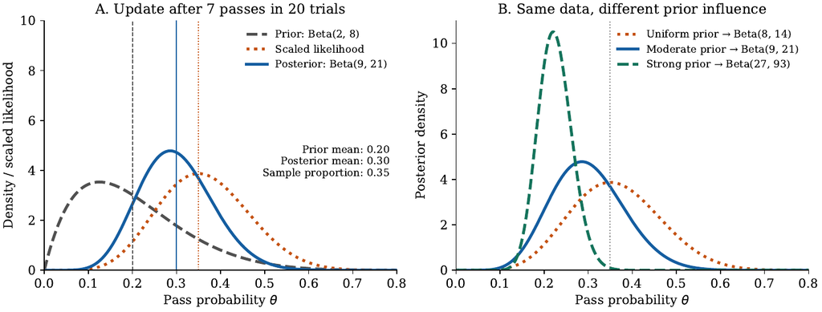

Lecture notes, Section 2.1. Panel A shows the update calculated above.

```r
stopifnot(abs(diff(pbeta(s21_hpd,s21_an,s21_bn))-.95)<1e-10)
```

## Credible-set calibration

**Concept.** Coverage at a fixed true rate averages over repeated samples. Prior average coverage also averages over the rate.

**Example.** Use ten trials and a uniform prior. There are eleven possible reported 90% equal-tailed intervals.

Find the interval for each possible count. At any true rate, sum the binomial probabilities of the counts whose intervals contain it.

```r
s21_s <- 0:10
s21_lo <- qbeta(.05,s21_s+1,11-s21_s)
s21_hi <- qbeta(.95,s21_s+1,11-s21_s)
s21_coverage <- function(theta) sum(dbinom(s21_s,10,theta)*
                                      (s21_lo<=theta & theta<=s21_hi))
s21_average <- sum((pbeta(s21_hi,s21_s+1,11-s21_s)-
                    pbeta(s21_lo,s21_s+1,11-s21_s))/11)
c(at_0.1=s21_coverage(.1),at_0.5=s21_coverage(.5),prior_average=s21_average)
```

```
##        at_0.1        at_0.5 prior_average
##     0.9298092     0.8906250     0.9000000
```

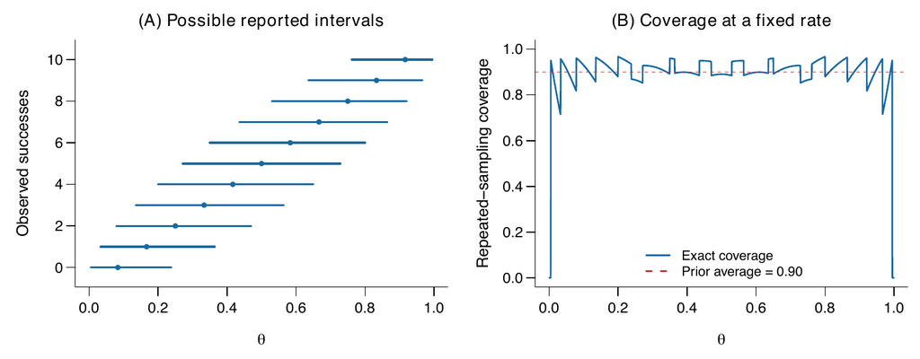

Lecture notes, Section 2.1. Coverage changes with the true rate even though its prior average is 0.90.

```r
stopifnot(abs(s21_average-.9)<1e-12)
```

Posterior probability and fixed-parameter coverage answer different questions. **Extension:** repeat this calculation under `Beta(2,8)` and verify the average using that prior, rather than a uniform average.

# Section 2.2 — Incident rates, exposure, and prediction

**Concept.** Counts update the Gamma shape and total exposure updates the rate. A future count mixes Poisson probabilities over the updated Gamma law.

**Example.** Observe eight daily incident counts, each with one day of exposure. Use a Gamma prior with shape and **rate** both equal to 2.

Add the total count and exposure to the prior parameters. Convert the updated rate and future exposure to the success probability used by R’s negative-binomial distribution.

```r
s22_counts <- c(1,0,3,2,1,4,2,3)
knitr::kable(data.frame(day=1:8,incidents=s22_counts,exposure_days=1))
```

| day | incidents | exposure_days |
| --- | --- | --- |
| 1 | 1 | 1 |
| 2 | 0 | 1 |
| 3 | 3 | 1 |
| 4 | 2 | 1 |
| 5 | 1 | 1 |
| 6 | 4 | 1 |
| 7 | 2 | 1 |
| 8 | 3 | 1 |

```r
s22_a0 <- 2; s22_b0 <- 2
s22_an <- s22_a0+sum(s22_counts)
s22_bn <- s22_b0+length(s22_counts)
s22_future_exposure <- 1
s22_prob <- s22_bn/(s22_bn+s22_future_exposure)
c(posterior_mean=s22_an/s22_bn,
 posterior_variance=s22_an/s22_bn^2,
 predictive_mean=s22_future_exposure*s22_an/s22_bn,
 predictive_variance=s22_future_exposure*s22_an/s22_bn+
   s22_future_exposure^2*s22_an/s22_bn^2,
 zero_probability=dnbinom(0,size=s22_an,prob=s22_prob))
```

```
##      posterior_mean  posterior_variance     predictive_mean predictive_variance
##           1.8000000           0.1800000           1.8000000           1.9800000
##    zero_probability
##           0.1798588
```

```r
stopifnot(s22_an==18,s22_bn==10,
 abs(dnbinom(0,size=s22_an,prob=s22_prob)-(10/11)^18)<1e-12)
```

The lecture figure uses ten future days to make the additional variance visible. Compute both predictive variances at the same expected count.

```r
s22_ten_days <- 10
s22_mean_ten <- s22_ten_days * s22_an / s22_bn
s22_rate_uncertainty <- s22_ten_days^2 * s22_an / s22_bn^2
c(mean = s22_mean_ten, plug_in_variance = s22_mean_ten,
  predictive_variance = s22_mean_ten + s22_rate_uncertainty)
```

```
##                mean    plug_in_variance predictive_variance
##                  18                  18                  36
```

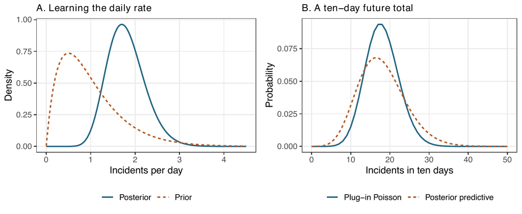

Lecture notes, Section 2.2. Both ten-day forecasts have mean 18.

The future count includes both Poisson variation and uncertain-rate variation. **Extension:** convert all exposures to hours. The hourly rate is the daily rate divided by 24; multiply the Gamma rate hyperparameters by 24 and verify unchanged prediction for one physical day.

# Section 2.3 — Additive information in a natural conjugate family

**Concept.** In a natural conjugate update, the sample adds sufficient statistics and sample size to the prior information coordinates.

**Example.** Observe `(0,1,2)` with unit sampling variance and a normal prior centered at one with precision two.

Add three units of precision and the sum of the observations. To check the evidence, compare direct numerical integration with the ratio of conjugate normalizers multiplied by the data’s base-density term.

```r
s23_x <- c(0,1,2)
s23_k0 <- 2; s23_m0 <- 1
s23_kn <- s23_k0+length(s23_x)
s23_mn <- (s23_k0*s23_m0+sum(s23_x))/s23_kn
c(posterior_mean=s23_mn,posterior_variance=1/s23_kn)
```

```
##     posterior_mean posterior_variance
##                1.0                0.2
```

```r
# Integrate the normalized likelihood times prior to check evidence.
s23_evidence <- integrate(function(mu) dnorm(mu,s23_m0,sqrt(1/s23_k0))*
 exp(vapply(mu,function(m)sum(dnorm(s23_x,m,1,log=TRUE)),0.)),
 -Inf,Inf)$value
s23_logZ <- function(k,m) .5*log(2*pi/k)+k*m^2/2
s23_logh <- sum(dnorm(s23_x,0,1,log=TRUE))
s23_formula <- exp(s23_logh+s23_logZ(s23_kn,s23_mn)-
                    s23_logZ(s23_k0,s23_m0))
c(numerical_evidence=s23_evidence,normalizer_ratio=s23_formula)
```

```
## numerical_evidence   normalizer_ratio
##          0.0147729          0.0147729
```

```r
stopifnot(abs(s23_mn-1)<1e-12,
 abs(s23_evidence-s23_formula)<1e-9)
```

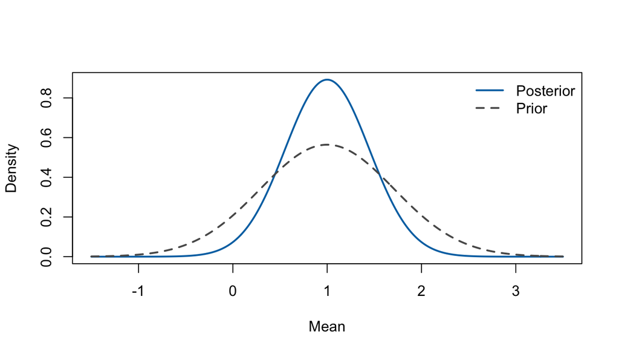

```r
s23_mu <- seq(-1.5, 3.5, length.out = 401)
s23_prior <- dnorm(s23_mu, s23_m0, 1 / sqrt(s23_k0))
s23_posterior <- dnorm(s23_mu, s23_mn, 1 / sqrt(s23_kn))
plot(s23_mu, s23_posterior, type = "l", col = "#0072B2", lwd = 2,
     xlab = "Mean", ylab = "Density")
lines(s23_mu, s23_prior, col = "grey35", lty = 2, lwd = 2)
legend("topright", c("Posterior", "Prior"), col = c("#0072B2", "grey35"),
       lty = c(1, 2), lwd = 2, bty = "n")
```

The evidence needs the base-density terms as well as the normalizer ratio. **Extension:** update sequentially with `(0)` and then `(1,2)`; reverse the batches and verify the same final information coordinates.

R 4.6.0 · BayesComp 0.1.0